# INMIGRACIÓN Y DIVERSIDAD EN ESPAÑA CRISIS ECONÓMICA Y GESTIÓN MUNICIPAL

### **Capítulo 8: SURASIÁTICOS EN MADRID Y BARCELONA: ENCARNANDO LA DIVERSIDAD [Autores: Nachatter Singh Garha, Andreu Domingo & Ana María López Sala]**

#### **Figura 8.1: Flujos inmigratorios de surasiáticos en España, por sexo y lugar de nacimiento, 2000-2014**

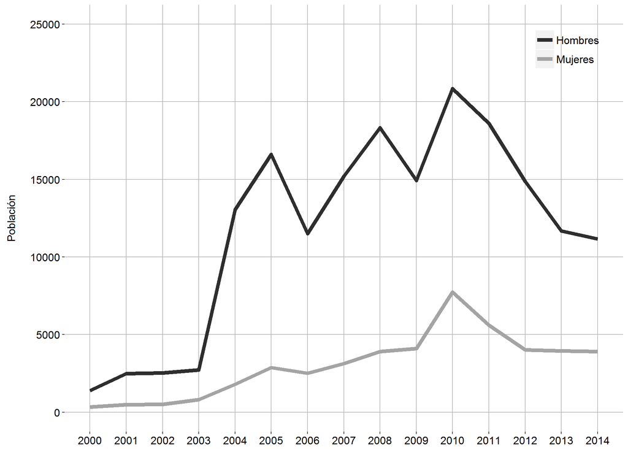

```r
library(ggplot2)
library(scales)
CAP8_GRAFIC1 <- read.csv("C:/Users/jgaleano/Desktop/ICARIA/CAP_8_GRAFIC1.csv", stringsAsFactors=FALSE)


CAP7_GRAFIC4$CAT <- factor(CAP7_GRAFIC4$CAT,  levels = c("< 20%","(20-30%]","(30-40%]", "(40-50%]", "(50-60%]", "(60-70%]"))

A <- ggplot(CAP8_GRAFIC1, aes(x=YEAR, y=POP, group=SEX))+
  geom_line(aes(colour = SEX), linetype = 1, size=2)+
  expand_limits(y=c(0,25000))+
   scale_x_continuous(breaks=c(2000,2001,2002,2003,2004,2005,2006,2007,2008,2009,2010,2011,2012,2013,2014))+
  scale_colour_manual(name="",
                     values=c( "#A4A4A4","#2E2E2E"), #"#D8D8D8","#6E6E6E", "#424242", "#1C1C1C"),
                     breaks=c("Males","Females"),
                     labels=c("Hombres","Mujeres"))+
   theme(plot.title = element_text(lineheight=5.6, size=20, face="bold"),
              legend.title = element_blank(),
              legend.text = element_text(colour="black", size = 12),
              legend.position = c(.90, .90),
              legend.background = element_rect(fill=NA),
              #legend.justification=c(6,2),
              #legend.direction = "vertical",
              #legend.key=element_rect(size=10),
              legend.key.size = unit(1.5, "lines"),
              axis.title.x = element_blank(),
              axis.text.x  = element_text(angle = 0,vjust=0.5, size=12,colour="black"),
              axis.title.y = element_text(colour="black", size=12),
              axis.text.y  = element_text(vjust=0.5, size=12,colour="black"),
              strip.text=element_text(angle = 0,vjust=0.5, size=13,colour="black", face = "bold"),
              panel.background = element_rect(fill = "#FFFFFF"),
              panel.grid = element_line(colour="#000000"),
              panel.grid.major=element_line(colour="#BDBDBD"),
              panel.grid.minor=element_line(colour="white"),
              plot.background = element_rect(fill = "#FFFFFF"))+
  ylab("Población\n")+ xlab("")
A
```

```r
setwd("C:\\Users\\jgaleano\\Desktop\\ICARIA\\GRAFICOS")
#ggsave("CAP8_FIG1.tiff", scale = 3, width = 9.8, height = 7, units = c("cm"), dpi = 300)
```

#### **Figura 8.2: Pirámide de la población nacida en el Sur de Asia empadronada en España, 2014**

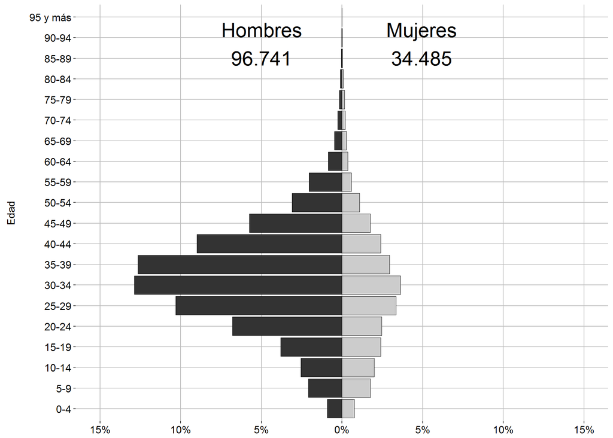

```r
library(ggplot2)
CAP8_GRAFIC2 <- read.csv("C:/Users/jgaleano/Desktop/ICARIA/CAP_8_GRAFIC2.csv", stringsAsFactors=FALSE)

CAP8_GRAFIC2$EDAD <- factor(CAP8_GRAFIC2$EDAD,
                   levels = c("0-4","5-9","10-14","15-19","20-24","25-29","30-34","35-39","40-44","45-49",
                              "50-54","55-59","60-64","65-69","70-74","75-79","80-84","85-89", "90-94", "95 y más"))


A<-ggplot(CAP8_GRAFIC2, aes(x=factor(EDAD), y=PROP2, fill=SEX))+
  geom_bar(data = CAP8_GRAFIC2[(CAP8_GRAFIC2$SEX=="Mujeres"),],
           colour = I("Black"),stat="identity", size=.3, colour="black",
           aes(x = EDAD, y = PROP2,fill = SEX), alpha = 1)+
  geom_bar(data = CAP8_GRAFIC2[(CAP8_GRAFIC2$SEX=="Hombres"),],
           colour = I("Black"),stat="identity", size=.3, colour="black",
           aes(x = EDAD, y = PROP2,fill = SEX), alpha = 1)+
  coord_flip()+
scale_y_continuous(limits=c(-15,15),breaks = c(-15, -10, -5,0,5,10,15),
                     labels = paste0(as.character(c(seq(15, 0, -5), seq(5, 15, 5))), "%")) +
   scale_fill_grey()+

  annotate("text", x = 18.7, y = -4.98, label = "Hombres\n96.741",size=8)+
  annotate("text", x = 18.7, y = 4.95, label = "Mujeres\n34.485",size=8)+


   theme(plot.title = element_text(lineheight=5.6, size=20, face="bold"),
              legend.title = element_blank(),
              legend.text = element_text(colour="black", size = 12),
              legend.position = "none",
              legend.background = element_rect(fill="#FFFFFF"),
              #legend.justification=c(0,1),
              legend.key.size = unit(1, "cm"),
              axis.title.x = element_blank(),
              axis.text.x  = element_text(angle = 0,vjust=0.5, size=12,colour="black"),
              axis.title.y = element_text(colour="black", size=12),
              axis.text.y  = element_text(vjust=0.5, size=12,colour="black"),
              strip.text=element_text(angle = 0,vjust=0.5, size=9,colour="black", face = "bold"),
              panel.background = element_rect(fill = "#FFFFFF"),
              panel.grid = element_line(colour="#000000"),
              panel.grid.major=element_line(colour="#BDBDBD"),
              panel.grid.minor=element_line(colour="white"),
              plot.background = element_rect(fill = "#FFFFFF"))+
  xlab("Edad\n")
A
```

```r
setwd("C:\\Users\\jgaleano\\Desktop\\ICARIA\\GRAFICOS")
#ggsave("CAP8_FIG2.tiff", scale = 3, width = 9.8, height = 7, units = c("cm"), dpi = 300)
```

#### **Figura 8.4: Principales municipios con población surasiática y distribución porcentual, España, 2014**

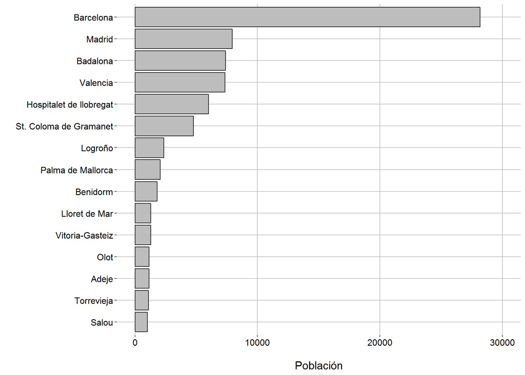

```r
library(ggplot2)
library(scales)
CAP8_GRAFIC4 <- read.csv("C:/Users/jgaleano/Desktop/ICARIA/CAP_8_GRAFIC4.csv", stringsAsFactors=FALSE)

CAP8_GRAFIC4$MUN <- factor(CAP8_GRAFIC4$MUN, levels = c("Salou","Torrevieja", "Adeje", "Olot","Vitoria-Gasteiz","Lloret de Mar",
                                                          "Benidorm","Palma de Mallorca","Logroño","St. Coloma de Gramanet",
                                                           "Hospitalet de llobregat","Valencia","Badalona","Madrid","Barcelona"))

A<- ggplot(CAP8_GRAFIC4, aes(x = MUN, y = POP, fill=MUN)) + geom_bar(stat = "identity", colour="black")+coord_flip()+
  #scale_y_continuous(breaks=c(0,0.05,0.1,0.15,0.2,0.25,0.3,0.35),labels=percent)+
  expand_limits(y=c(0,30000))+

    scale_fill_manual(values = c("#BDBDBD","#BDBDBD","#BDBDBD","#BDBDBD","#BDBDBD","#BDBDBD","#BDBDBD",
                               "#BDBDBD","#BDBDBD","#BDBDBD","#BDBDBD","#BDBDBD","#BDBDBD","#BDBDBD","#BDBDBD"))+
   theme(plot.title = element_text(lineheight=5.6, size=20, face="bold"),
              legend.title = element_blank(),
              legend.text = element_text(colour="black", size = 12),
              legend.position = "none",
              legend.background = element_rect(fill="#FFFFFF"),
              legend.direction = "horizontal",
              legend.key=element_rect(size=10),
              legend.key.size = unit(2.5, "lines"),

              axis.title.x = element_text(colour="black", size=15),
              axis.text.x  = element_text(angle = 00,vjust=0.5, size=12,colour="black"),
              axis.title.y = element_text(colour="black", size=12),
              axis.text.y  = element_text(vjust=0.5, size=12,colour="black"),
              strip.text=element_text(angle = 0,vjust=0.5, size=13,colour="black", face = "bold"),
              panel.background = element_rect(fill = "#FFFFFF"),
              panel.grid = element_line(colour="#000000"),
              panel.grid.major=element_line(colour="#BDBDBD"),
              panel.grid.minor=element_line(colour="white"),
              plot.background = element_rect(fill = "#FFFFFF"))+
  xlab("")+ ylab("\nPoblación")
A
```

```r
setwd("C:\\Users\\jgaleano\\Desktop\\ICARIA\\GRAFICOS")
#ggsave("CAP8_FIG4.tiff", scale = 3, width = 9.8, height = 7, units = c("cm"), dpi = 300)
```

#### **Figura 8.5: Índice de disimilitud de la población surasiática residente en Madrid y Barcelona, sobre la tendencia de los 10 principales municipios donde se encuentra cada una de las poblaciones, 2000-2014**

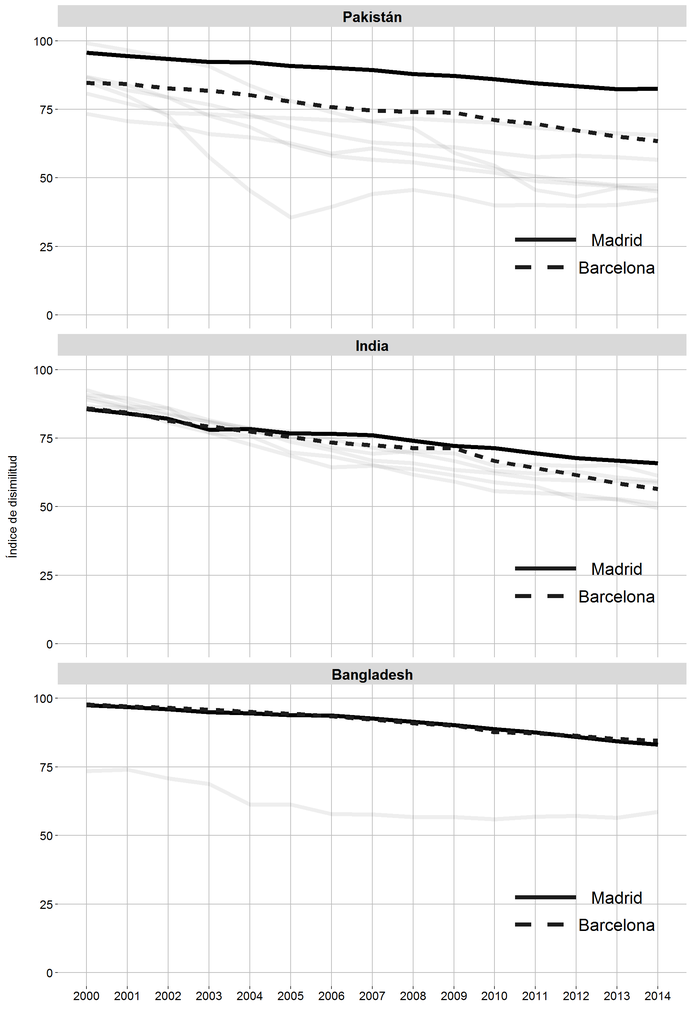

```r
library(ggplot2)
library(scales)
CAP8_GRAFIC5 <- read.csv("C:/Users/jgaleano/Desktop/ICARIA/CAP_8_GRAFIC5_PAKISTAN.csv", stringsAsFactors=FALSE)

CAP8_GRAFIC5$PAIS <- factor(CAP8_GRAFIC5$PAIS, levels = c("Pakistán","India", "Bangladesh"))

CAP8_GRAFIC5$MUN <- factor(CAP8_GRAFIC5$MUN, levels = c("Benidorm","Badalona","Hospitalet de Llobregat","Valencia","St. Coloma de Gramenet","Vitoria-Gasteiz","Madrid","Barcelona","Palma de Mallorca"))


A <- ggplot(CAP8_GRAFIC5, aes(x=YEAR, y=D, group=MUN))+
     geom_line(aes(colour = MUN,alpha=TRAN,linetype=factor(LINE)), size=2)+
     expand_limits(y=c(0,100))+
     scale_x_continuous(breaks=c(2000,2001,2002,2003,2004,2005,2006,2007,2008,2009,2010,2011,2012,2013,2014))+
     scale_colour_manual(name="",
                     values=c( "#585858","#585858","#585858","#585858","#585858","#585858","#000000","#1C1C1C","#585858"),
                     breaks=c("Benidorm","Badalona","Hospitalet de Llobregat","Valencia","St. Coloma de Gramenet",
                               "Vitoria-Gasteiz","Madrid","Barcelona","Palma de Mallorca"),
                     labels=c("Benidorm","Badalona","Hospitalet de Llobregat","Valencia","St. Coloma de Gramenet",
                               "Vitoria-Gasteiz","Madrid","Barcelona","Palma de Mallorca"))+

   facet_wrap(~PAIS, ncol = 1)+
   annotate("segment", x = 2010.5, xend = 2012, y = 27.5, yend = 27.5,size=2,colour = c("#1C1C1C","#1C1C1C","#1C1C1C") )+
   annotate("text", label = "Madrid", size = 6, x = 2013, y = 27.5)+
   annotate("segment", x = 2010.5, xend = 2012, y = 17.5, yend = 17.5,size=2, linetype= 2,colour = c("#1C1C1C","#1C1C1C","#1C1C1C") )+
   annotate("text", label = "Barcelona", size = 6, x = 2013, y = 17.5)+
   theme(plot.title = element_text(lineheight=5.6, size=20, face="bold"),
              legend.title = element_blank(),
              legend.text = element_text(colour="black", size = 12),
              legend.position = "none",
              legend.background = element_rect(fill="#FFFFFF"),
              legend.direction = "horizontal",
              legend.key=element_rect(size=10),
              legend.key.size = unit(2.5, "lines"),

              axis.title.x = element_text(colour="black", size=17),
              axis.text.x  = element_text(angle = 00,vjust=0.5, size=12,colour="black"),
              axis.title.y = element_text(colour="black", size=12),
              axis.text.y  = element_text(vjust=0.5, size=12,colour="black"),
              strip.text=element_text(angle = 0,vjust=0.5, size=15,colour="black", face = "bold"),
              panel.background = element_rect(fill = "#FFFFFF"),
              panel.grid = element_line(colour="#000000"),
              panel.grid.major=element_line(colour="#BDBDBD"),
              panel.grid.minor=element_line(colour="white"),
              plot.background = element_rect(fill = "#FFFFFF"))+
  xlab("")+ ylab("Índice de disimilitud\n")
A
```

```r
setwd("C:\\Users\\jgaleano\\Desktop\\ICARIA\\GRAFICOS")
#ggsave("CAP8_FIG5.tiff", scale = 3, width = 9.8, height = 14.5, units = c("cm"), dpi = 300)
```

#### **Figura 8.11: Concentración de la población surasiática en el barrio de El Raval, 10 primeras nacionalizaciones, y pirámides de población surasiática y española, 2014**

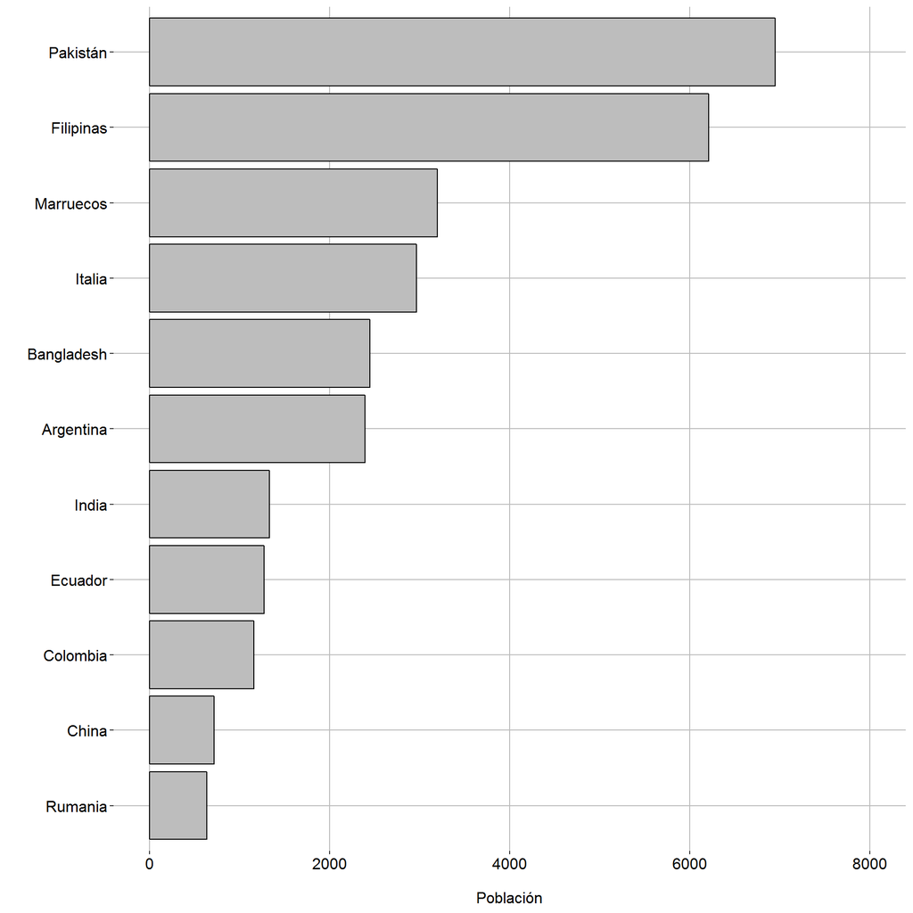

```r
library(ggplot2)
library(scales)
CAP8_GRAFIC11 <- read.csv("C:/Users/jgaleano/Desktop/ICARIA/CAP_8_GRAFIC11_RAVAL.csv", stringsAsFactors=FALSE)

CAP8_GRAFIC11$PAIS <- factor(CAP8_GRAFIC11$PAIS, levels = c("Rumania","China","Colombia","Ecuador","India","Argentina",
                                                          "Bangladesh","Italia","Marruecos","Filipinas","Pakistán"))

A<- ggplot(CAP8_GRAFIC11, aes(x = PAIS, y = POP, fill=PAIS)) + geom_bar(stat = "identity", colour="black")+coord_flip()+
    expand_limits(y=c(0,8000))+
    scale_fill_manual(values = c("#BDBDBD","#BDBDBD","#BDBDBD","#BDBDBD","#BDBDBD","#BDBDBD","#BDBDBD",
                               "#BDBDBD","#BDBDBD","#BDBDBD","#BDBDBD"))+
    theme(plot.title = element_text(lineheight=5.6, size=20, face="bold"),
              legend.title = element_blank(),
              legend.text = element_text(colour="black", size = 15),
              legend.position = "none",
              legend.background = element_rect(fill="#FFFFFF"),
              #legend.justification=c(6,2),
              legend.direction = "horizontal",
              legend.key=element_rect(size=10),
              legend.key.size = unit(2.5, "lines"),

              axis.title.x = element_text(colour="black", size=12),
              axis.text.x  = element_text(angle = 00,vjust=0.5, size=12,colour="black"),
              axis.title.y = element_text(colour="black", size=12),
              axis.text.y  = element_text(vjust=0.5, size=12,colour="black"),
              strip.text=element_text(angle = 0,vjust=0.5, size=12,colour="black", face = "bold"),
              panel.background = element_rect(fill = "#FFFFFF"),
              panel.grid = element_line(colour="#000000"),
              panel.grid.major=element_line(colour="#BDBDBD"),
              panel.grid.minor=element_line(colour="white"),
              plot.background = element_rect(fill = "#FFFFFF"))+
  xlab("")+ ylab("\nPoblación")
A
```

```r
setwd("C:\\Users\\jgaleano\\Desktop\\ICARIA\\GRAFICOS")
#ggsave("CAP8_FIG11.tiff", scale = 3, width = 9.8, height = 9.8, units = c("cm"), dpi = 300)
```

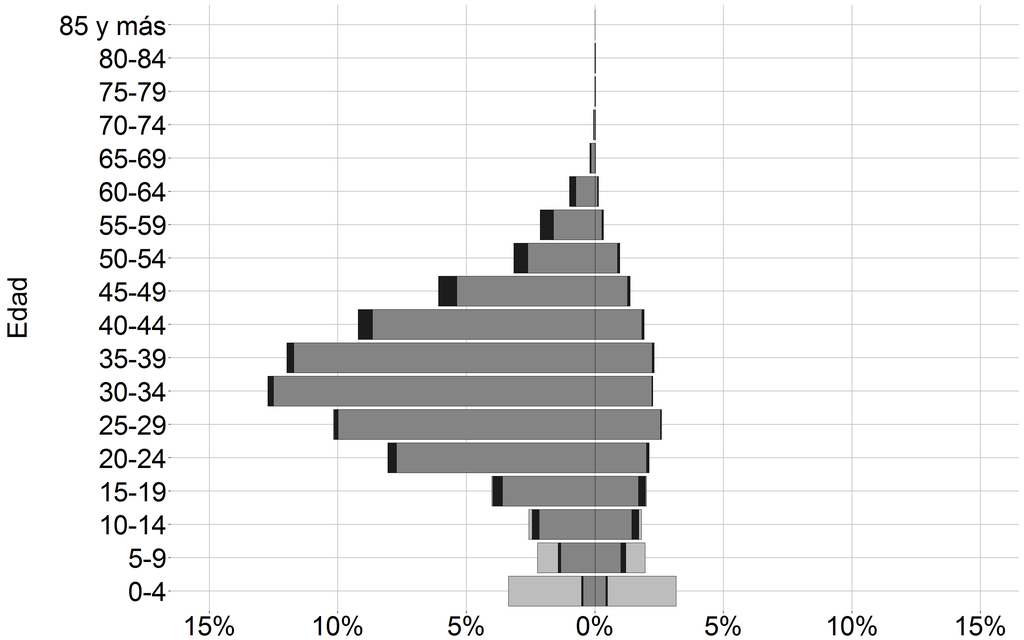

```r
library(ggplot2)
library(scales)
CAP8_GRAFIC11 <- read.csv("C:/Users/jgaleano/Desktop/ICARIA/CAP_8_GRAFIC11_RAVAL_PIRAMIDE1.csv", stringsAsFactors=FALSE)

CAP8_GRAFIC11$EDAD <- factor(CAP8_GRAFIC11$EDAD,
                   levels = c("0-4","5-9","10-14","15-19","20-24","25-29","30-34","35-39","40-44","45-49",
                              "50-54","55-59","60-64","65-69","70-74","75-79","80-84", "85 y más"))

CAP8_GRAFIC11$CAT <- factor(CAP8_GRAFIC11$CAT,
                   levels = c("Surasiático nacido en España", "Surasiático nacido en Surasia","Español nacido en Surasia" ))

A<-ggplot(CAP8_GRAFIC11, aes(x=EDAD, y=POP, fill=SEX))+
  geom_bar(data = CAP8_GRAFIC11[(CAP8_GRAFIC11$SEX2=="Mujeres-Surasiático nacido en Surasia"|
                                         CAP8_GRAFIC11$SEX2=="Mujeres-Español nacido en Surasia"|
                                         CAP8_GRAFIC11$SEX2=="Mujeres-Surasiático nacido en España"),],
           colour = I("Black"),stat="identity", size=.3, colour="black",
           aes(x = EDAD, y = POP,fill = CAT), alpha = 1)+
  geom_bar(data = CAP8_GRAFIC11[(CAP8_GRAFIC11$SEX2=="Hombres-Surasiático nacido en Surasia"|
                                           CAP8_GRAFIC11$SEX2=="Hombres-Español nacido en Surasia"|
                                           CAP8_GRAFIC11$SEX2=="Hombres-Surasiático nacido en España"),],
           colour = I("Black"),stat="identity", size=.3, colour="black",
           aes(x = EDAD, y = POP,fill = CAT), alpha = 1)+
  coord_flip()+
 scale_y_continuous(limits=c(-15,15),breaks = c(-15, -10, -5,0,5,10,15),
                     labels = paste0(as.character(c(seq(15, 0, -5), seq(5, 15, 5))), "%")) +
  scale_fill_manual(values = c("#BDBDBD","#848484","#1C1C1C"))+
   theme(plot.title = element_text(lineheight=5.6, size=20, face="bold"),
              legend.title = element_blank(),
              legend.text = element_text(colour="black", size = 15),
              legend.position="none",
              legend.background = element_rect(fill="#FFFFFF"),
              legend.justification=c(0,1),
              legend.key.size = unit(1, "cm"),
              axis.title.x = element_blank(),
              axis.text.x  = element_text(angle = 0,vjust=0.5, size=30,colour="black"),
              axis.title.y = element_text(colour="black", size=30),
              axis.text.y  = element_text(vjust=0.5, size=30,colour="black"),
              strip.text=element_text(angle = 0,vjust=0.5, size=9,colour="black", face = "bold"),
              panel.background = element_rect(fill = "#FFFFFF"),
              panel.grid = element_line(colour="#000000"),
              panel.grid.major=element_line(colour="#BDBDBD"),
              panel.grid.minor=element_line(colour="white"),
              plot.background = element_rect(fill = "#FFFFFF"))+
  xlab("Edad\n")
A
```

```r
setwd("C:\\Users\\jgaleano\\Desktop\\ICARIA\\GRAFICOS")
#ggsave("CAP8_FIG11_PIRAMIDE_RAVAL.tiff", scale = 3, width = 9.8, height = 7, units = c("cm"), dpi = 300)
```

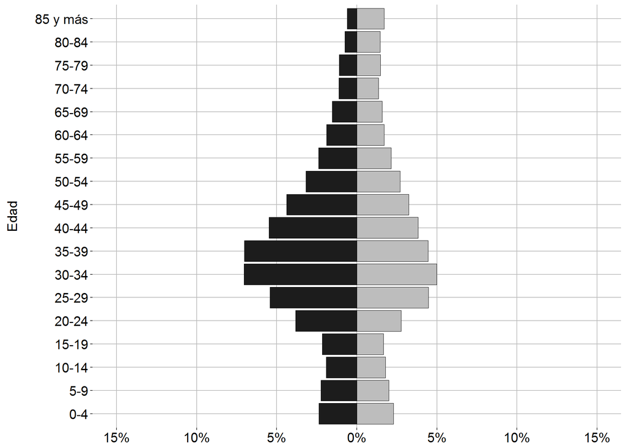

```r
library(ggplot2)
library(scales)
CAP8_GRAFIC11 <- read.csv("C:/Users/jgaleano/Desktop/ICARIA/CAP_8_GRAFIC11_RAVAL_PIRAMIDE2.csv", stringsAsFactors=FALSE)

CAP8_GRAFIC11$EDAD <- factor(CAP8_GRAFIC11$EDAD,
                   levels = c("0-4","5-9","10-14","15-19","20-24","25-29","30-34","35-39","40-44","45-49",
                              "50-54","55-59","60-64","65-69","70-74","75-79","80-84", "85 y más"))

#CAP8_GRAFIC11$CAT <- factor(CAP8_GRAFIC11$CAT,
 #                  levels = c("Surasiático nacido en España", "Surasiático nacido en Surasia","Español nacido en Surasia" ))

A<-ggplot(CAP8_GRAFIC11, aes(x=EDAD, y=PROP, fill=SEX))+
  geom_bar(data = CAP8_GRAFIC11[(CAP8_GRAFIC11$SEX=="Mujeres"),],
           colour = I("Black"),stat="identity", size=.3, colour="black",
           aes(x = EDAD, y = PROP,fill = SEX), alpha = 1)+
  geom_bar(data = CAP8_GRAFIC11[(CAP8_GRAFIC11$SEX=="Hombres"),],
           colour = I("Black"),stat="identity", size=.3, colour="black",
           aes(x = EDAD, y = PROP,fill = SEX), alpha = 1)+
  coord_flip()+
 scale_y_continuous(limits=c(-15,15),breaks = c(-15, -10, -5,0,5,10,15),
                     labels = paste0(as.character(c(seq(15, 0, -5), seq(5, 15, 5))), "%")) +
  scale_fill_manual(values = c("#1C1C1C","#BDBDBD"))+
   theme(plot.title = element_text(lineheight=5.6, size=20, face="bold"),
              legend.title = element_blank(),
              legend.text = element_text(colour="black", size = 15),
              legend.position="none",
              legend.background = element_rect(fill="#FFFFFF"),
              legend.justification=c(0,1),
              legend.key.size = unit(1, "cm"),
              axis.title.x = element_blank(),
              axis.text.x  = element_text(angle = 0,vjust=0.5, size=15,colour="black"),
              axis.title.y = element_text(colour="black", size=15),
              axis.text.y  = element_text(vjust=0.5, size=15,colour="black"),
              strip.text=element_text(angle = 0,vjust=0.5, size=9,colour="black", face = "bold"),
              panel.background = element_rect(fill = "#FFFFFF"),
              panel.grid = element_line(colour="#000000"),
              panel.grid.major=element_line(colour="#BDBDBD"),
              panel.grid.minor=element_line(colour="white"),
              plot.background = element_rect(fill = "#FFFFFF"))+
  xlab("Edad\n")
A
```

```r
setwd("C:\\Users\\jgaleano\\Desktop\\ICARIA\\GRAFICOS")
#ggsave("CAP8_FIG11_PIRAMIDE_RAVAL2.tiff", scale = 3, width = 9.8, height = 7, units = c("cm"), dpi = 300)
```

#### **Figura 8.12: Concentración de la población surasiática en el barrio de Lavapiés, 10 primeras nacionalizaciones, y pirámides de población surasiática y española, 2014**

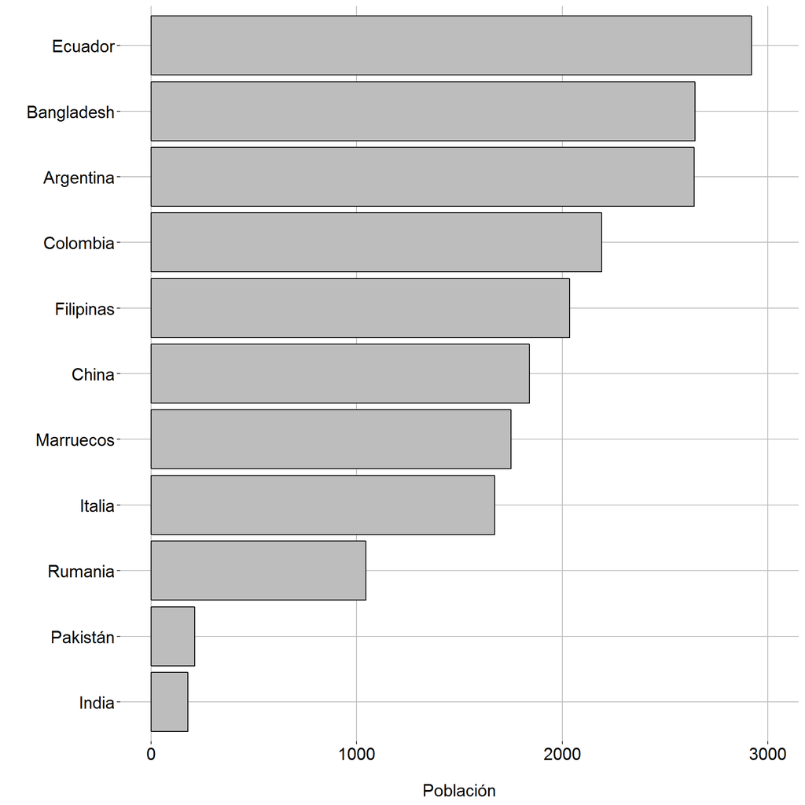

```r
library(ggplot2)
library(scales)
CAP8_GRAFIC11 <- read.csv("C:/Users/jgaleano/Desktop/ICARIA/CAP_8_GRAFIC11_LAVAPIES.csv", stringsAsFactors=FALSE)

CAP8_GRAFIC11$PAIS <- factor(CAP8_GRAFIC11$PAIS, levels = c("India","Pakistán","Rumania","Italia","Marruecos","China",
                                                            "Filipinas","Colombia","Argentina","Bangladesh","Ecuador"))

A<- ggplot(CAP8_GRAFIC11, aes(x = PAIS, y = POP, fill=PAIS)) + geom_bar(stat = "identity", colour="black")+coord_flip()+
  expand_limits(y=c(0,3000))+

    scale_fill_manual(values = c("#BDBDBD","#BDBDBD","#BDBDBD","#BDBDBD","#BDBDBD","#BDBDBD","#BDBDBD",
                               "#BDBDBD","#BDBDBD","#BDBDBD","#BDBDBD"))+
   theme(plot.title = element_text(lineheight=5.6, size=20, face="bold"),
              legend.title = element_blank(),
              legend.text = element_text(colour="black", size = 15),
              legend.position = "none",
              legend.background = element_rect(fill="#FFFFFF"),
              legend.direction = "horizontal",
              legend.key=element_rect(size=10),
              legend.key.size = unit(2.5, "lines"),
              axis.title.x = element_text(colour="black", size=15),
              axis.text.x  = element_text(angle = 00,vjust=0.5, size=15,colour="black"),
              axis.title.y = element_text(colour="black", size=15),
              axis.text.y  = element_text(vjust=0.5, size=15,colour="black"),
              strip.text=element_text(angle = 0,vjust=0.5, size=13,colour="black", face = "bold"),
              panel.background = element_rect(fill = "#FFFFFF"),
              panel.grid = element_line(colour="#000000"),
              panel.grid.major=element_line(colour="#BDBDBD"),
              panel.grid.minor=element_line(colour="white"),
              plot.background = element_rect(fill = "#FFFFFF"))+
  xlab("")+ ylab("\nPoblación")
A
```

```r
setwd("C:\\Users\\jgaleano\\Desktop\\ICARIA\\GRAFICOS")
#ggsave("CAP8_FIG11_B.tiff", scale = 3, width = 9.8, height = 9.8, units = c("cm"), dpi = 300)
```

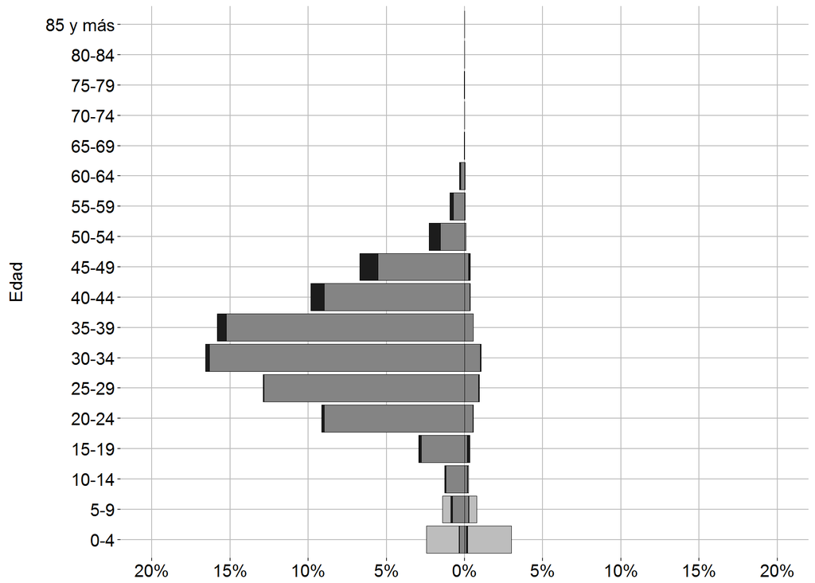

```r
library(ggplot2)
library(scales)
CAP8_GRAFIC11 <- read.csv("C:/Users/jgaleano/Desktop/ICARIA/CAP_8_GRAFIC11_LAVAPIES_PIRAMIDE1.csv", stringsAsFactors=FALSE)

CAP8_GRAFIC11$EDAD <- factor(CAP8_GRAFIC11$EDAD,
                   levels = c("0-4","5-9","10-14","15-19","20-24","25-29","30-34","35-39","40-44","45-49",
                              "50-54","55-59","60-64","65-69","70-74","75-79","80-84", "85 y más"))

CAP8_GRAFIC11$CAT <- factor(CAP8_GRAFIC11$CAT,
                   levels = c("Surasiático nacido en España", "Surasiático nacido en Surasia","Español nacido en Surasia" ))

A<-ggplot(CAP8_GRAFIC11, aes(x=EDAD, y=POP, fill=SEX))+
  geom_bar(data = CAP8_GRAFIC11[(CAP8_GRAFIC11$SEX2=="Mujeres-Surasiático nacido en Surasia"|
                                         CAP8_GRAFIC11$SEX2=="Mujeres-Español nacido en Surasia"|
                                         CAP8_GRAFIC11$SEX2=="Mujeres-Surasiático nacido en España"),],
           colour = I("Black"),stat="identity", size=.3, colour="black",
           aes(x = EDAD, y = POP,fill = CAT), alpha = 1)+
  geom_bar(data = CAP8_GRAFIC11[(CAP8_GRAFIC11$SEX2=="Hombres-Surasiático nacido en Surasia"|
                                           CAP8_GRAFIC11$SEX2=="Hombres-Español nacido en Surasia"|
                                           CAP8_GRAFIC11$SEX2=="Hombres-Surasiático nacido en España"),],
           colour = I("Black"),stat="identity", size=.3, colour="black",
           aes(x = EDAD, y = POP,fill = CAT), alpha = 1)+
  coord_flip()+
 scale_y_continuous(limits=c(-20,20),breaks = c(-20,-15, -10, -5,0,5,10,15,20),
                     labels = paste0(as.character(c(seq(20, 0, -5), seq(5, 20, 5))), "%")) +
  scale_fill_manual(values = c("#BDBDBD","#848484","#1C1C1C"))+
   theme(plot.title = element_text(lineheight=5.6, size=20, face="bold"),
              legend.title = element_blank(),
              legend.text = element_text(colour="black", size = 15),
              legend.position="none",
              legend.background = element_rect(fill="#FFFFFF"),
              legend.justification=c(0,1),
              legend.key.size = unit(1, "cm"),
              axis.title.x = element_blank(),
              axis.text.x  = element_text(angle = 0,vjust=0.5, size=15,colour="black"),
              axis.title.y = element_text(colour="black", size=15),
              axis.text.y  = element_text(vjust=0.5, size=15,colour="black"),
              strip.text=element_text(angle = 0,vjust=0.5, size=9,colour="black", face = "bold"),
              panel.background = element_rect(fill = "#FFFFFF"),
              panel.grid = element_line(colour="#000000"),
              panel.grid.major=element_line(colour="#BDBDBD"),
              panel.grid.minor=element_line(colour="white"),
              plot.background = element_rect(fill = "#FFFFFF"))+
  xlab("Edad\n")
A
```

```r
setwd("C:\\Users\\jgaleano\\Desktop\\ICARIA\\GRAFICOS")
#ggsave("CAP8_FIG11_PIRAMIDE_LAVAPIES.tiff", scale = 3, width = 9.8, height = 7, units = c("cm"), dpi = 300)
```

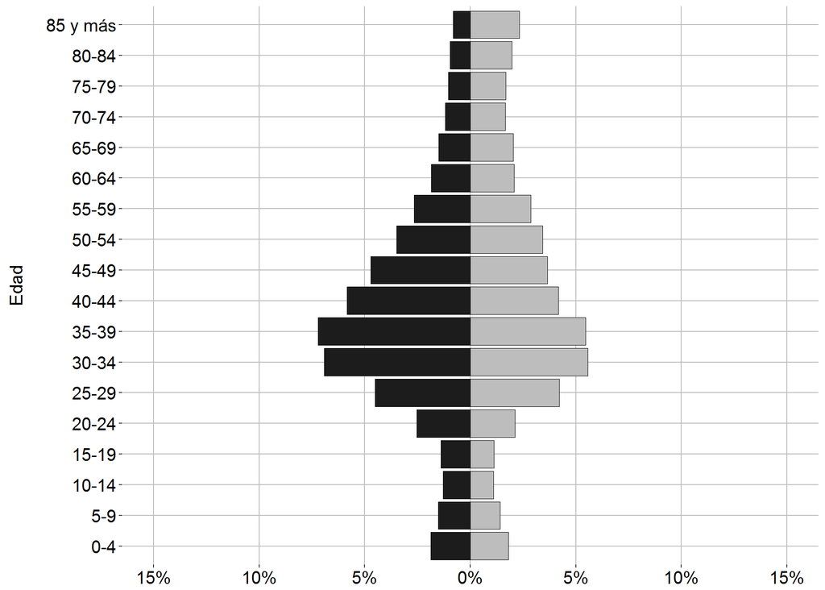

```r
library(ggplot2)
library(scales)
CAP8_GRAFIC11 <- read.csv("C:/Users/jgaleano/Desktop/ICARIA/CAP_8_GRAFIC11_LAVAPIES_PIRAMIDE2.csv", stringsAsFactors=FALSE)

CAP8_GRAFIC11$EDAD <- factor(CAP8_GRAFIC11$EDAD,
                   levels = c("0-4","5-9","10-14","15-19","20-24","25-29","30-34","35-39","40-44","45-49",
                              "50-54","55-59","60-64","65-69","70-74","75-79","80-84", "85 y más"))

#CAP8_GRAFIC11$CAT <- factor(CAP8_GRAFIC11$CAT,
 #                  levels = c("Surasiático nacido en España", "Surasiático nacido en Surasia","Español nacido en Surasia" ))

A<-ggplot(CAP8_GRAFIC11, aes(x=EDAD, y=PROP, fill=SEX))+
  geom_bar(data = CAP8_GRAFIC11[(CAP8_GRAFIC11$SEX=="Mujeres"),],
           colour = I("Black"),stat="identity", size=.3, colour="black",
           aes(x = EDAD, y = PROP,fill = SEX), alpha = 1)+
  geom_bar(data = CAP8_GRAFIC11[(CAP8_GRAFIC11$SEX=="Hombres"),],
           colour = I("Black"),stat="identity", size=.3, colour="black",
           aes(x = EDAD, y = PROP,fill = SEX), alpha = 1)+
  coord_flip()+
 scale_y_continuous(limits=c(-15,15),breaks = c(-15, -10, -5,0,5,10,15),
                     labels = paste0(as.character(c(seq(15, 0, -5), seq(5, 15, 5))), "%")) +
  scale_fill_manual(values = c("#1C1C1C","#BDBDBD"))+
   theme(plot.title = element_text(lineheight=5.6, size=20, face="bold"),
              legend.title = element_blank(),
              legend.text = element_text(colour="black", size = 15),
              legend.position="none",
              legend.background = element_rect(fill="#FFFFFF"),
              legend.justification=c(0,1),
              legend.key.size = unit(1, "cm"),
              axis.title.x = element_blank(),
              axis.text.x  = element_text(angle = 0,vjust=0.5, size=15,colour="black"),
              axis.title.y = element_text(colour="black", size=15),
              axis.text.y  = element_text(vjust=0.5, size=15,colour="black"),
              strip.text=element_text(angle = 0,vjust=0.5, size=9,colour="black", face = "bold"),
              panel.background = element_rect(fill = "#FFFFFF"),
              panel.grid = element_line(colour="#000000"),
              panel.grid.major=element_line(colour="#BDBDBD"),
              panel.grid.minor=element_line(colour="white"),
              plot.background = element_rect(fill = "#FFFFFF"))+
  xlab("Edad\n")
A
```

```r
setwd("C:\\Users\\jgaleano\\Desktop\\ICARIA\\GRAFICOS")
#ggsave("CAP8_FIG11_PIRAMIDE_LAVAPIES2.tiff", scale = 3, width = 9.8, height = 7, units = c("cm"),dpi = 300, limitsize = TRUE)
```